# San Francisco Bay Study Fish Data

Brian Mahardja

10/29/2021

## San Francisco Bay Study

Taken from California Department of Fish and Wildlife (CDFW) Website (https://wildlife.ca.gov/Conservation/Delta/Bay-Study):

The San Francisco Bay Study (Bay Study) was established in 1980 to determine the effects of freshwater outflow on the abundance and distribution of fish and mobile crustaceans in the San Francisco Estuary, primarily downstream of the Sacramento-San Joaquin Delta.

Sampling ranges from south of the Dumbarton Bridge in South San Francisco Bay, to just west of Alcatraz Island in Central San Francisco Bay, throughout San Pablo and Suisun bays, north to the confluence Steamboat and Cache sloughs on the Sacramento River, and east to Old River Flats on the San Joaquin River. The open water or boat survey samples 52 stations monthly: 35 original stations, 7 stations added in 1988, 4 stations added in 1991, and 6 stations added in 1994. The study included a beach seine survey, discontinued in 1987, and a shore-based ringnet survey for crabs, discontinued in 1994.

The Bay Study uses a 42-foot stern trawler to sample with 2 trawl nets at each open water station. The otter trawl, which samples demersal fishes, shrimp, and crabs, is towed against the current at a standard engine rpm for 5 minutes then retrieved. The midwater trawl, which samples pelagic fishes, is towed with the current at a standard engine rpm for 12 minutes and retrieved obliquely such that all depths are sampled equally. The open water survey included a plankton net that sampled larval fish and crustaceans, but this was discontinued in 1989.

Fish, caridean shrimp, and brachyuran crabs are identified, measured, and counted. Shrimp and crabs are also sexed. Sampling effort is quantified (i.e. distance towed, volume of water filtered) and salinity, water temperature, Secchi depth, and station depth are measured; wave height, tide, cloud cover, and tow direction are categorized. The length, catch, and effort data is used to calculate catch-per-unit-effort (CPUE) by species and age class. The CPUE data is used to calculate monthly and annual abundance indices, which are used to track seasonal and annual population trends. Important factors that control or regulate abundance and distribution of fish and mobile crustaceans in the estuary include salinity, temperature, freshwater outflow, ocean temperature, upwelling, and surface currents, primary and secondary productivity, and introduced species. We are interested in how species respond to changes in the physical environment on several temporal scales – seasonal, annual, decadal, and longer.

## Load data and show sampling effort

Load data for key species using Sam’s LTMRdata package and show map with CDFW Bay Study stations. Yellow indicates stations we will be using for the study per Denise’s suggestion and the CDFW station “regions”.

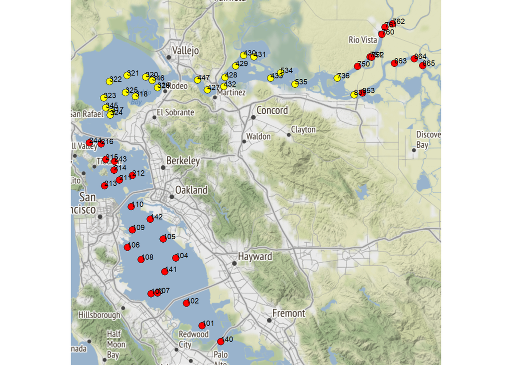

```r
#Load all species except for Striped Bass (Delta Smelt, Longfin Smelt, Threadfin Shad, American Shad, Northern Anchovy, and Pacific Herring)

BayStudy_allfish<-LTMRdata::fish(sources="Baystudy", species=c("Hypomesus transpacificus","Spirinchus thaleichthys","Dorosoma petenense",
                                                               "Alosa sapidissima","Engraulis mordax","Clupea pallasii"), size_cutoff=NULL,remove_unknown_lengths=FALSE)

#Load age-0 Striped Bass
#Remove age-1 Striped Bass and NOTE that we assume that unmeasured Striped Bass are age-0
BayStudy_Striped_Bass <-LTMRdata::fish(sources="Baystudy", species="Morone saxatilis", size_cutoff=NULL,remove_unknown_lengths=FALSE) %>% filter(is.na(Length)|Length<150)

#Extract coordinates
BayStudyCoords<-BayStudy_Striped_Bass %>% group_by(Station) %>% summarise(Latitude=mean(Latitude),Longitude=mean(Longitude))
BayStudyCoords<-BayStudyCoords[complete.cases(BayStudyCoords), ]
BayStudyCoords_studyregion<-BayStudyCoords %>% filter(Station>300) %>%
  filter(Station<700|Station %in% c(736,837))

#Create map
buffer <- 0.05
coordDict = list(
  'minLat' = min(BayStudyCoords$Latitude) - buffer,
  'maxLat' = max(BayStudyCoords$Latitude) + buffer,
  'minLon' = min(BayStudyCoords$Longitude) - buffer,
  'maxLon' = max(BayStudyCoords$Longitude) + buffer
)

map_obj <- get_stamenmap(
  bbox = c(left = coordDict[['minLon']], bottom = coordDict[['minLat']], right = coordDict[['maxLon']], top = coordDict[['maxLat']]),
  zoom = 10,
  maptype = 'terrain'
)

# plot the map
map <- ggmap(map_obj) +
  theme_void() +
  geom_point(data = BayStudyCoords, aes(x = Longitude, y = Latitude), shape = 21, fill = 'red', size = 3) +
  geom_point(data = BayStudyCoords_studyregion, aes(x = Longitude, y = Latitude), shape = 21, fill = 'yellow', size = 3)+
  geom_text(data = BayStudyCoords, aes(label = Station, x = Longitude, y = Latitude), vjust = 0, hjust = 0, size=2.5)

map
```

## Process data

Per Denise’s suggestion, we will be subsetting data from just April to October and the yellow sites from the map above.

```r
#Limit the data to just April to October
BayStudy_full <- bind_rows(BayStudy_allfish,BayStudy_Striped_Bass) %>%
  mutate(Month=month(Date)) %>% filter(Month %in% c(4:10)) %>%
  #and only between San Pablo Bay and the confluence
  #https://nrm.dfg.ca.gov/FileHandler.ashx?DocumentID=185001&inline
  mutate(Station=as.numeric(Station))

BayStudy_combined <- BayStudy_full %>%
  filter(Station>300) %>%
  filter(Station<700|Station %in% c(736,837))

unique(BayStudy_combined$Station)
```

```
##  [1] 320 321 322 323 324 325 326 427 428 429 430 431 432 433 534 535 736 837 317
## [20] 318 319 345 346 447
```

Check sampling effort through the years for all stations (separated by gear)

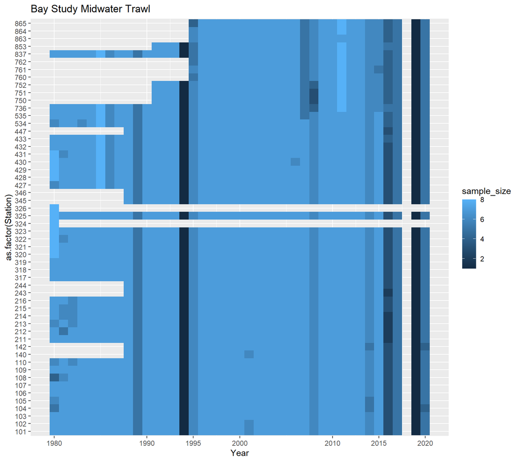

```r
##Sample size
Baystudy_sample_size <- BayStudy_full %>% group_by(SampleID,Date,Month,Station,Method) %>%
  summarise(Latitude=mean(Latitude),Longitude=mean(Longitude)) %>% mutate(sample_size=1,Year=year(Date)) %>%
  group_by(Year,Station,Method,Latitude,Longitude) %>% summarise(sample_size=sum(sample_size))

#Plot effort across stations and years for midwater trawl
ggplot(Baystudy_sample_size %>% filter(Method== "Midwater trawl"),aes(x=Year,y=as.factor(Station),fill=sample_size))+geom_tile()+
  scale_x_continuous(breaks=c(1970,1980,1990,1995,2000,2010,2015,2020)) + labs(title= "Bay Study Midwater Trawl")
```

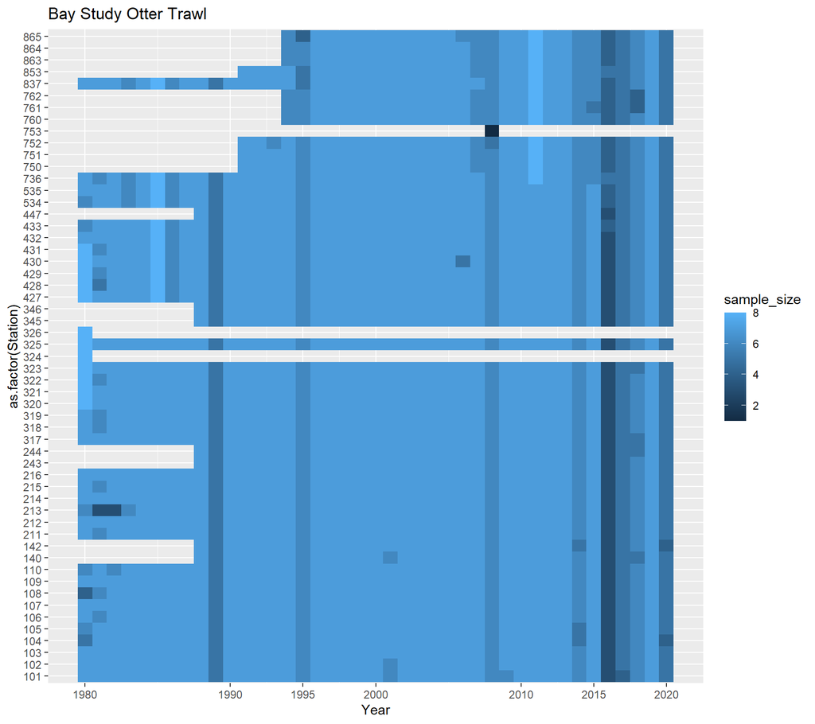

```r
#Plot effort across stations and years for otter trawl
ggplot(Baystudy_sample_size %>% filter(Method== "Otter trawl"),aes(x=Year,y=as.factor(Station),fill=sample_size))+geom_tile()+
  scale_x_continuous(breaks=c(1970,1980,1990,1995,2000,2010,2015,2020)) + labs(title= "Bay Study Otter Trawl")
```

Check sampling effort through the years for the annual stations (separated by gear)

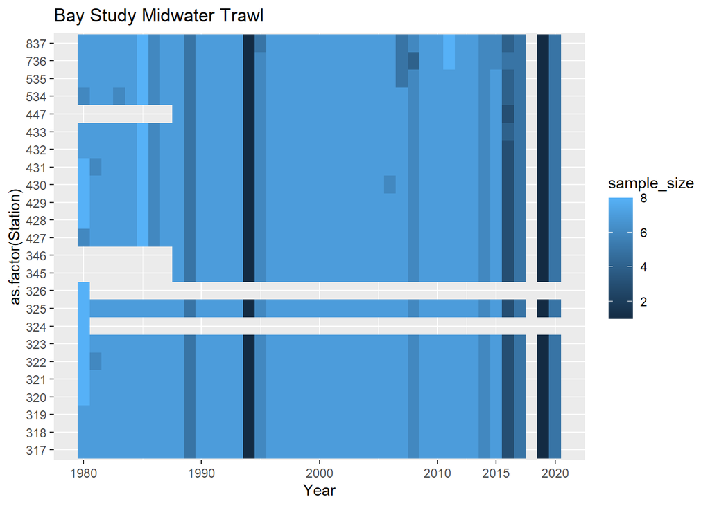

```r
##Sample size
Baystudy_sample_size <- BayStudy_combined %>% group_by(SampleID,Date,Month,Station,Method) %>%
  summarise(Latitude=mean(Latitude),Longitude=mean(Longitude)) %>% mutate(sample_size=1,Year=year(Date)) %>%
  group_by(Year,Station,Method,Latitude,Longitude) %>% summarise(sample_size=sum(sample_size))

#Plot effort across stations and years for midwater trawl
ggplot(Baystudy_sample_size %>% filter(Method== "Midwater trawl"),aes(x=Year,y=as.factor(Station),fill=sample_size))+geom_tile()+
  scale_x_continuous(breaks=c(1970,1980,1990,2000,2010,2015,2020)) + labs(title= "Bay Study Midwater Trawl")
```